# Homework #2

Julie Lenoir

13/03/2018

## Exercice 1: playing with data

The `sample.csv` file (in the `data` folder) contains the data of an experiment conducted on 100 patients. Patients belonged to one of the following groups: control, treatment 1 and treatment 2. For each patient, their level of aneurisms was recorded four times throughout the year.

With this data:

1. [**easy**] load the `sample.csv` file (careful, it may contain columns name)

```r
path = "~/data/"
filename = "sample.csv"
data = read.csv(paste0(path, filename), header = TRUE)
```

2. [**easy**] currently, the `ID` variable is stored as factors. Convert this variable from factors to characters

```r
class(data$ID)
```

```
## [1] "factor"
```

```r
data$ID <- as.character(data$ID)
class(data$ID)
```

```
## [1] "character"
```

3. [**trivial**] as in the class, clean the `Gender` variable to get rid of `M` and `F`

```r
data$Gender[data$Gender == "M"] <- "m"
data$Gender[data$Gender == "F"] <- "f"
data$Gender <- droplevels(data$Gender)
```

4. [**easy**] print summary statistics on the current data set

I let out the first column which corresponds to patients ID.

Since gender and group are resp. character and factor, the summary function is only going to give us the number of individual per category/level, and not the mean/ min/ max/ quantiles.

```r
knitr::kable(summary(data[,2:9]))
```

|  | Gender | Group | BloodPressure | Age | Aneurisms_q1 | Aneurisms_q2 | Aneurisms_q3 | Aneurisms_q4 |
| --- | --- | --- | --- | --- | --- | --- | --- | --- |
|  | f:39 | Control :30 | Min. : 62.0 | Min. :12.10 | Min. : 65.0 | Min. : 80.0 | Min. :105.0 | Min. :116.0 |
|  | m:61 | Treatment1:35 | 1st Qu.:107.5 | 1st Qu.:14.78 | 1st Qu.:118.0 | 1st Qu.:131.5 | 1st Qu.:182.5 | 1st Qu.:186.8 |
|  | NA | Treatment2:35 | Median :117.5 | Median :16.65 | Median :158.0 | Median :162.5 | Median :217.0 | Median :219.0 |
|  | NA | NA | Mean :118.6 | Mean :16.42 | Mean :158.8 | Mean :168.0 | Mean :219.8 | Mean :217.9 |
|  | NA | NA | 3rd Qu.:133.0 | 3rd Qu.:18.30 | 3rd Qu.:188.0 | 3rd Qu.:196.8 | 3rd Qu.:248.2 | 3rd Qu.:244.2 |
|  | NA | NA | Max. :173.0 | Max. :20.00 | Max. :260.0 | Max. :283.0 | Max. :323.0 | Max. :315.0 |

5. [**medium**] create a new variable, `Aneurisms_mean`, which corresponds to the mean aneurism across the four quarters, for each patient

```r
data$Aneurism_mean = apply(data[,6:9], 1, mean)
head(data[,6:10])
```

```
##   Aneurisms_q1 Aneurisms_q2 Aneurisms_q3 Aneurisms_q4 Aneurism_mean
## 1          114          140          202          237        173.25
## 2          148          209          248          248        213.25
## 3          196          251          122          177        186.50
## 4          199          140          233          220        198.00
## 5          188          120          222          228        189.50
## 6          260          266          320          294        285.00
```

6. [**harder**] plot the distribution of `Aneurisms_mean` for both genders, and then for male and female separately

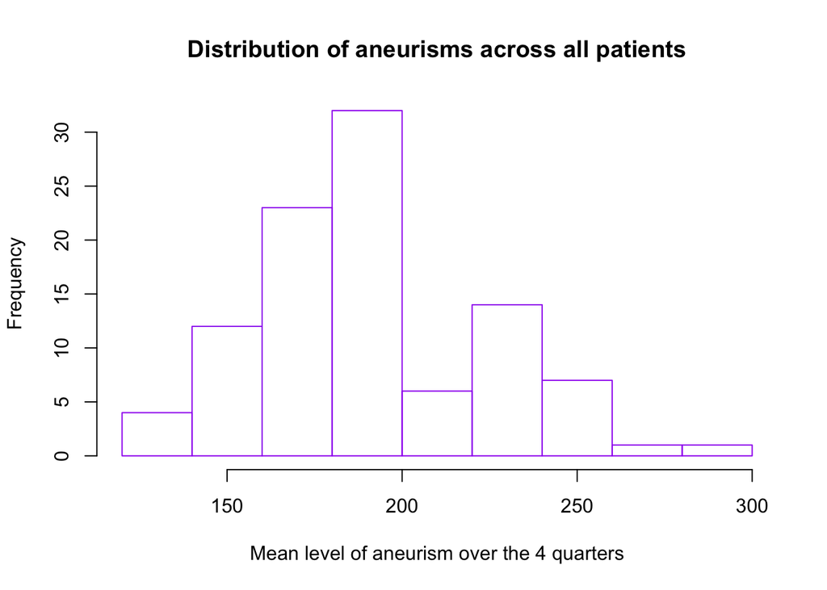

```r
# Over all distribution
hist(data$Aneurism_mean,
     main = "Distribution of aneurisms across all patients",
     xlab = "Mean level of aneurism over the 4 quarters",
     border = "purple")
```

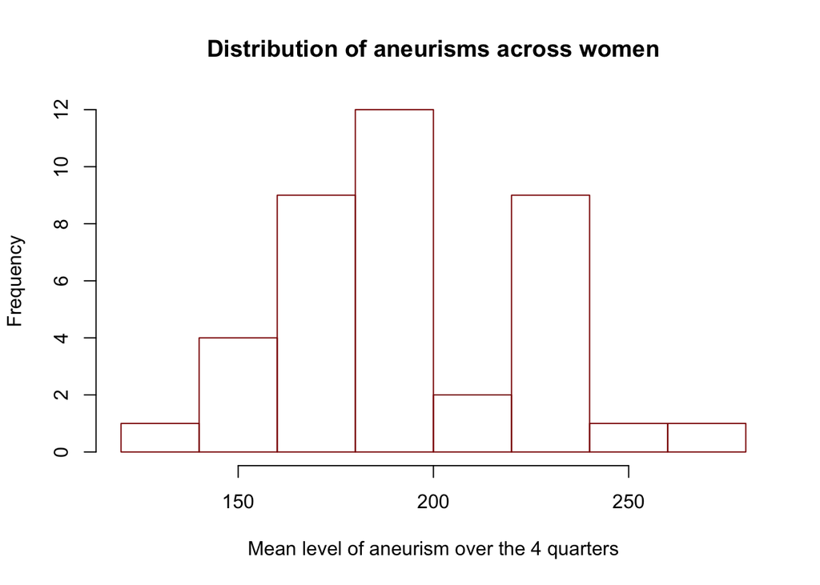

```r
plot( by(data$Aneurism_mean, data$Gender, hist, plot = FALSE)$f,
     main = "Distribution of aneurisms across women",
     xlab = "Mean level of aneurism over the 4 quarters",
     border = "dark red")
```

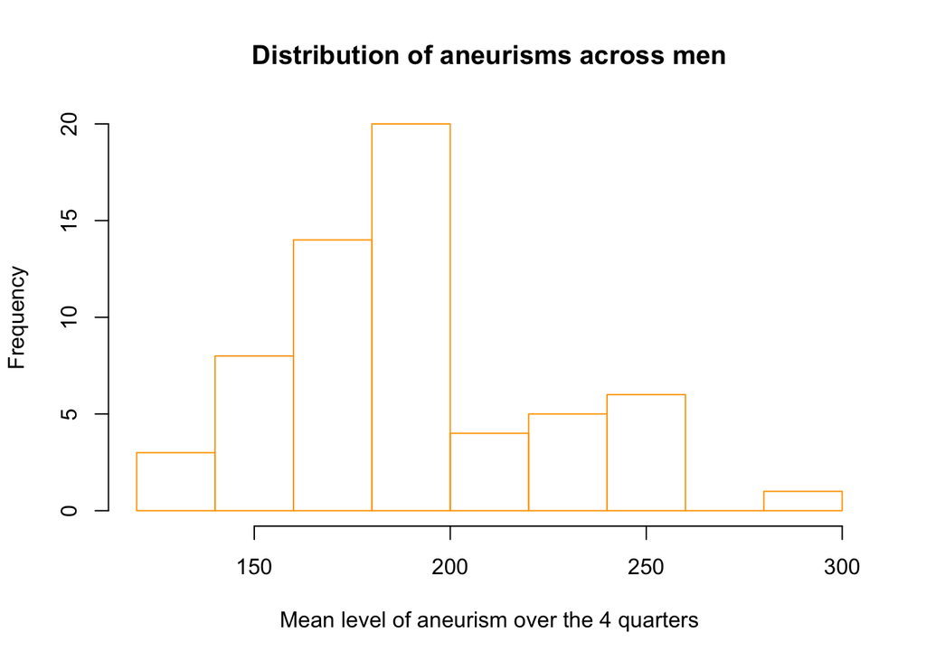

```r
plot( by(data$Aneurism_mean, data$Gender, hist, plot = FALSE)$m,
     main = "Distribution of aneurisms across men",
     xlab = "Mean level of aneurism over the 4 quarters",
     border = "orange")
```

## Exercice 2: scaling to $(0,1)$

Write a function `rescale` that takes a vector as input and returns a corresponding vector of values scaled to lie in the range 0 to 1.

```r
scale_unit = function(d){
  #scales a vector with a range (a, b) to a vector with the range (0,1)
  #scales the columns of a matrix to the range (0,1)
  if(class(d) == "numeric"){
  a = (d - min(d))/(max(d) - min(d))
  return(a)
  }
  else if(class(d) == "data.frame" | class(d) == "matrix"){
  warning("Input is either a data.frame or a matrix, rescaling is done by columns.")
  a = apply(d, 2, function(x) (x - min(x))/(max(x) - min(x)))
  return(a)
  }
  else{
  warning("Input is neither a vector, a matrix or a dataframe, the function cannot be applied.")
  }
}

scale_unit(c(-2, 0, 6, 9))
```

```
## [1] 0.0000000 0.1818182 0.7272727 1.0000000
```

```r
scale_unit(matrix(c(1, 10, 30,
                 3, 15, 35,
                 5, 21, 38), nrow = 3, ncol = 3))
```

```
##           [,1]  [,2]      [,3]
## [1,] 0.0000000 0.000 0.0000000
## [2,] 0.3103448 0.375 0.4848485
## [3,] 1.0000000 1.000 1.0000000
```

## Exercice 3: testing

Design at least 3 tests – using the `testthat` package – that check whether your `scale_unit` function is working properly.

```r
test = scale_unit(c(1, 2, 3, 4, 5))

require(testthat)
test_that("Testing scale_unit function", {
  all.equal(c(0.00, 0.25, 0.50, 0.75, 1.00), test, info = "Test for basic vector")
  expect_true(min(test) == 0 , "Test min = 0")
  expect_true(max(test) == 1 , "Test max = 1")
  expect_true(mean(test) ==
                ( mean(test) - min(test) ) /
                ( max(test) - min(test) ), "Test mean was properly scaled" )
})
```

# Exercice 4: scaling to $(a,b)$

Write a function `scale` that takes a vector with a range $(0,1)$ as input and returns a vector of values scaled to lie in the range `a` to `b`.

*Note*: if the original vector does not lie in the $(0,1)$ interval, warn the user that the computation is erroned.

```r
scale = function(x, a, b){
  #scales a vector with a range (0, 1) to a vector with the range (a,b)
  #the input should be a vector
  if(min(x) < 0 && max(x) > 1){
    warning("This function applies only to vectors with a range (0,1).")
  }
  else{
    scaled = x*(b-a) + a
    return(scaled)
  }
}

scale(c(0, 0.25, 0.5, 0.75, 1), 1, 5)
```

```
## [1] 1 2 3 4 5
```

# Exercice 5: composition

Write a function that scales an arbitrary vector `x` to a range `a` and `b`, where `a` and `b` are arguments of the function with default value `0` and `1`.

```r
general_scale = function(x, a = 0, b = 1){
  #scales an arbitrary vector x to a range (a, b)
  #by default, a=0 and b=1 such that general_scale = scale_unit
  step1 = scale_unit(x)
  step2 = scale(step1, a, b)
  return(step2)
}

Test = c(1, 2, 3, 4, 5)
#Let's test for our "by default" statement

general_scale(Test) == scale_unit(Test)
```

```
## [1] TRUE TRUE TRUE TRUE TRUE
```

```r
general_scale(Test, 5, 10)
```

```
## [1]  5.00  6.25  7.50  8.75 10.00
```

# Exercice 6: visual checking

Using randown draws from a $(0,1)$ uniform distrbution, produce a plot that shows why using directly `scale` on a non-unit vector produces the wrong result. **Be creative**.

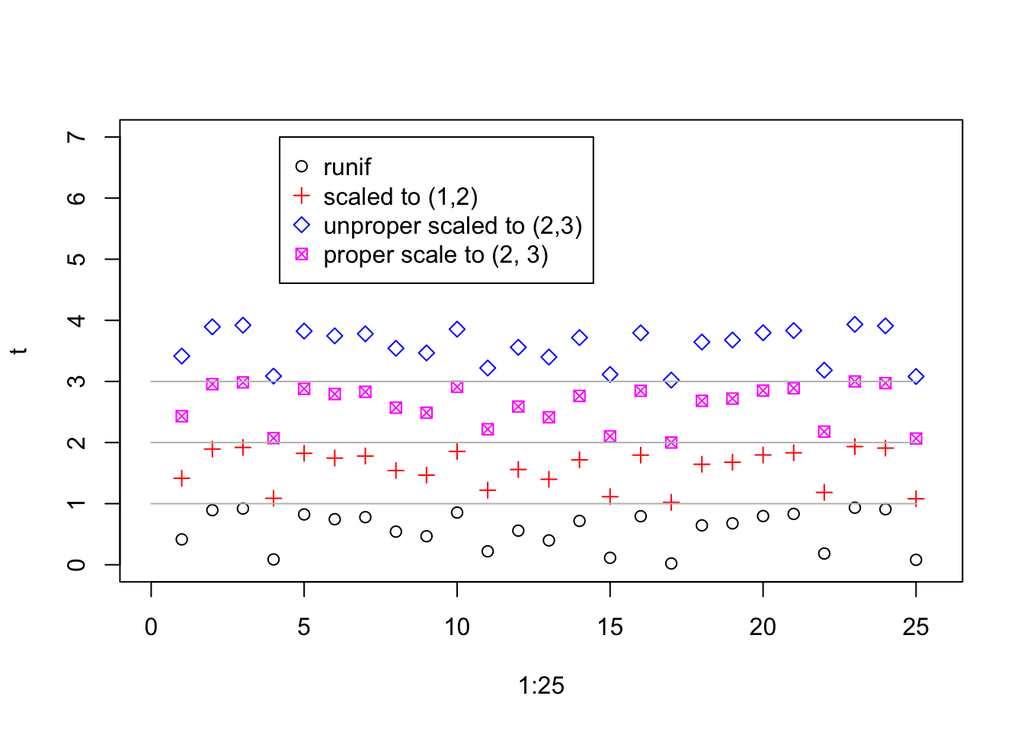

```r
t = runif(25)
h = scale(t, 1, 2)
j = scale(h, 2, 3)
k = general_scale(h, 2, 3)


plot(1:25, t, xlim =c(0,25.5), ylim = c(0,7))
points(1:25, h, col=2, pch=3)
points(1:25, j, col=4, pch=5)
points(1:25, k, col=6, pch=7)
lines(0:25, rep(1, 26), col="gray")
lines(0:25, rep(2, 26), col="gray")
lines(0:25, rep(3, 26), col="gray")
legend(4.2, 7,
       c("runif", "scaled to (1,2)", "unproper scaled to (2,3)", "proper scale to (2, 3)"),
       col = c(1, 2, 4, 6),
       pch = c(1, 3, 5, 7))
```

Indeed in the graph, the first scaling is working: we get points that belong to the range (1, 2). However, when we try to rescale those points to the range (2, 3), we end up with points in the range (3, 4). The function scale is therefore not giving the proper result when applied to vector out of the range (0, 1).

However, when we use the function “general_scale”, we get the proper result.